# Experiment 7: Iris Flower Classification

## Aim

To develop a supervised machine learning model using Python and Scikit-learn to classify Iris flowers into Setosa, Versicolor, and Virginica based on sepal and petal measurements.

## Learning Objectives

- Understand a labelled classification dataset.
- Explore and visualize the dataset.
- Split the data into training and testing sets.
- Train Logistic Regression, K-Nearest Neighbours, and Decision Tree classifiers.
- Evaluate models using accuracy, precision, recall, F1-score, and a confusion matrix.
- Compare model performance and predict the species of a new flower.

## Software Requirements

Python, Jupyter Notebook, NumPy, Pandas, Matplotlib, Seaborn, and Scikit-learn.

```python
import numpy as np
import pandas as pd
import matplotlib.pyplot as plt
import seaborn as sns

from sklearn.datasets import load_iris
from sklearn.model_selection import train_test_split, cross_val_score
from sklearn.preprocessing import StandardScaler
from sklearn.pipeline import Pipeline
from sklearn.linear_model import LogisticRegression
from sklearn.neighbors import KNeighborsClassifier
from sklearn.tree import DecisionTreeClassifier
from sklearn.metrics import (
    accuracy_score, precision_score, recall_score, f1_score,
    confusion_matrix, classification_report, ConfusionMatrixDisplay
)

iris = load_iris()

X = pd.DataFrame(iris.data, columns=iris.feature_names)
y = pd.Series(iris.target, name="target")

print(X.head())
print(y.head())
print("Target classes:", iris.target_names)
```

```
   sepal length (cm)  sepal width (cm)  petal length (cm)  petal width (cm)
0                5.1               3.5                1.4               0.2
1                4.9               3.0                1.4               0.2
2                4.7               3.2                1.3               0.2
3                4.6               3.1                1.5               0.2
4                5.0               3.6                1.4               0.2
0    0
1    0
2    0
3    0
4    0
Name: target, dtype: int64
Target classes: ['setosa' 'versicolor' 'virginica']
```

## Dataset Description

The Iris dataset contains 150 flower samples, four numerical input features, and three target classes. Each class contains 50 samples.

| Feature | Description | Unit |
| --- | --- | --- |
| Sepal length | Length of the sepal | cm |
| Sepal width | Width of the sepal | cm |
| Petal length | Length of the petal | cm |
| Petal width | Width of the petal | cm |
| Target | Iris flower species | Setosa, Versicolor, Virginica |

The input features are the sepal and petal measurements, while the target variable represents the species.

```python
print("Dataset shape:", X.shape)
print("\nDataset information:")
X.info()

print("\nStatistical description:")
print(X.describe())

print("\nClass distribution:")
print(y.value_counts().sort_index())

print("\nMissing values:")
print(X.isnull().sum())

print("\nNumber of samples:", X.shape[0])
print("Number of features:", X.shape[1])
print("Number of classes:", y.nunique())
print("Most frequent class:", iris.target_names[y.mode()[0]])
```

```
Dataset shape: (150, 4)

Dataset information:
<class 'pandas.DataFrame'>
RangeIndex: 150 entries, 0 to 149
Data columns (total 4 columns):
 #   Column             Non-Null Count  Dtype
---  ------             --------------  -----
 0   sepal length (cm)  150 non-null    float64
 1   sepal width (cm)   150 non-null    float64
 2   petal length (cm)  150 non-null    float64
 3   petal width (cm)   150 non-null    float64
dtypes: float64(4)
memory usage: 4.8 KB

Statistical description:
       sepal length (cm)  sepal width (cm)  petal length (cm)  \
count         150.000000        150.000000         150.000000
mean            5.843333          3.057333           3.758000
std             0.828066          0.435866           1.765298
min             4.300000          2.000000           1.000000
25%             5.100000          2.800000           1.600000
50%             5.800000          3.000000           4.350000
75%             6.400000          3.300000           5.100000
max             7.900000          4.400000           6.900000

       petal width (cm)
count        150.000000
mean           1.199333
std            0.762238
min            0.100000
25%            0.300000
50%            1.300000
75%            1.800000
max            2.500000

Class distribution:
target
0    50
1    50
```

[output cut: 37 more lines]

```
1    50
2    50
Name: count, dtype: int64

Missing values:
sepal length (cm)    0
sepal width (cm)     0
petal length (cm)    0
petal width (cm)     0
dtype: int64

Number of samples: 150
Number of features: 4
Number of classes: 3
Most frequent class: setosa
```

## Data Visualization

Data visualization helps identify relationships between features and differences among the three Iris species. A pair plot compares feature distributions, while a correlation heatmap displays correlations between numerical features.

Petal length and petal width generally provide the clearest separation between the species.

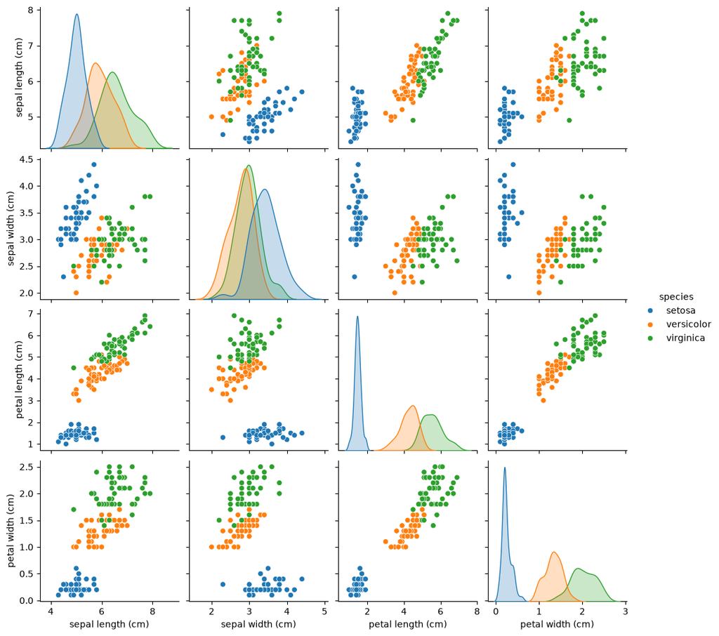

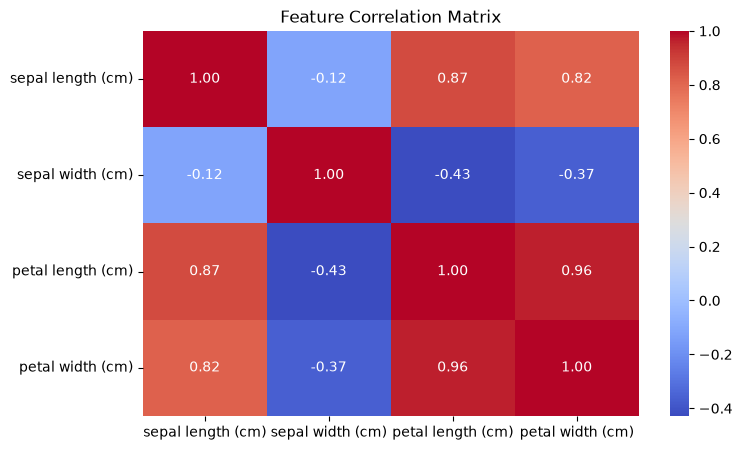

```python
df = X.copy()
df["species"] = iris.target_names[y.to_numpy()]

sns.pairplot(df, hue="species")
plt.show()

plt.figure(figsize=(8, 5))
sns.heatmap(X.corr(), annot=True, cmap="coolwarm", fmt=".2f")
plt.title("Feature Correlation Matrix")
plt.show()
```

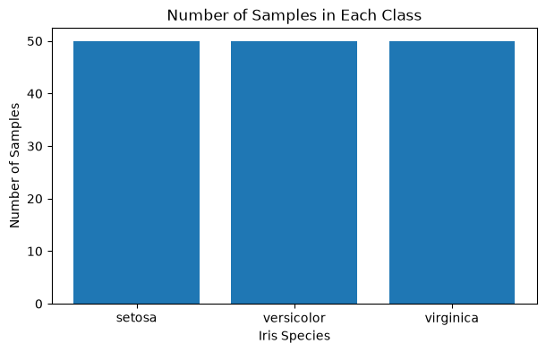

```python
class_counts = pd.Series(
    iris.target_names[y.value_counts().sort_index().index],
    index=iris.target_names
)

counts = y.value_counts().sort_index()

plt.figure(figsize=(7, 4))
plt.bar(iris.target_names, counts.values)
plt.xlabel("Iris Species")
plt.ylabel("Number of Samples")
plt.title("Number of Samples in Each Class")
plt.show()
```

## Train-Test Split

The dataset is divided into 80% training data and 20% testing data. The training set is used to train the model, while the testing set evaluates its performance on unseen samples.

The `stratify=y` parameter preserves the class proportions in both sets. The `random_state=42` parameter makes the split reproducible.

```python
X_train, X_test, y_train, y_test = train_test_split(
    X,
    y,
    test_size=0.20,
    random_state=42,
    stratify=y
)

print("Training features:", X_train.shape)
print("Testing features:", X_test.shape)
print("Training samples:", len(y_train))
print("Testing samples:", len(y_test))
```

```
Training features: (120, 4)
Testing features: (30, 4)
Training samples: 120
Testing samples: 30
```

## Model 1: Logistic Regression

Logistic Regression is a supervised classification algorithm that estimates the probability of an input belonging to a particular class. Although its name contains the word regression, it is used for classification tasks.

StandardScaler is applied through a Pipeline to standardize the input features. The scaler is fitted only on the training data to prevent data leakage.

```python
lr_model = Pipeline([
    ("scaler", StandardScaler()),
    ("classifier", LogisticRegression(max_iter=200))
])

lr_model.fit(X_train, y_train)
y_pred = lr_model.predict(X_test)

print("Accuracy:", accuracy_score(y_test, y_pred))
print("Precision:", precision_score(y_test, y_pred, average="weighted"))
print("Recall:", recall_score(y_test, y_pred, average="weighted"))
print("F1-score:", f1_score(y_test, y_pred, average="weighted"))

print("\nClassification Report:")
print(classification_report(
    y_test, y_pred,
    target_names=iris.target_names,
    zero_division=0
))
```

```
Accuracy: 0.9333333333333333
Precision: 0.9333333333333333
Recall: 0.9333333333333333
F1-score: 0.9333333333333333

Classification Report:
              precision    recall  f1-score   support

      setosa       1.00      1.00      1.00        10
  versicolor       0.90      0.90      0.90        10
   virginica       0.90      0.90      0.90        10

    accuracy                           0.93        30
   macro avg       0.93      0.93      0.93        30
weighted avg       0.93      0.93      0.93        30
```

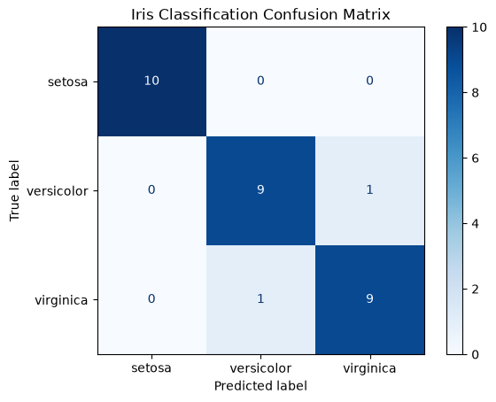

```python
cm = confusion_matrix(y_test, y_pred)

disp = ConfusionMatrixDisplay(
    confusion_matrix=cm,
    display_labels=iris.target_names
)

disp.plot(cmap="Blues")
plt.title("Iris Classification Confusion Matrix")
plt.show()
```

## Confusion Matrix Interpretation

A confusion matrix compares actual classes with predicted classes.

- Rows represent actual classes.
- Columns represent predicted classes.
- Diagonal elements represent correct predictions.
- Off-diagonal elements represent incorrect predictions.

A good classifier has high values along the main diagonal and few values outside it.

## Prediction of a New Flower

The trained Logistic Regression model is used to predict the species of a new flower using its sepal length, sepal width, petal length, and petal width.

The predicted probabilities indicate the model's estimated probability for each species.

```python
new_flower = pd.DataFrame(
    [[5.1, 3.5, 1.4, 0.2]],
    columns=iris.feature_names
)

prediction = lr_model.predict(new_flower)
probability = lr_model.predict_proba(new_flower)

print("Predicted species:", iris.target_names[prediction[0]])

print("\nClass probabilities:")
for species, prob in zip(iris.target_names, probability[0]):
    print(f"{species}: {prob:.4f}")
```

```
Predicted species: setosa

Class probabilities:
setosa: 0.9808
versicolor: 0.0192
virginica: 0.0000
```

## Comparison of Classification Algorithms

Three supervised learning algorithms are evaluated using the same training and testing split.

1. Logistic Regression: A linear classification algorithm.
2. K-Nearest Neighbours (KNN): Classifies a sample based on the classes of its nearest neighbours.
3. Decision Tree: Classifies samples using a sequence of feature-based decision rules.

Weighted precision, recall, and F1-score are used to compare model performance.

```python
knn_model = Pipeline([
    ("scaler", StandardScaler()),
    ("classifier", KNeighborsClassifier(n_neighbors=5))
])

dt_model = DecisionTreeClassifier(random_state=42)

models = {
    "Logistic Regression": lr_model,
    "KNN": knn_model,
    "Decision Tree": dt_model
}

results = []
predictions = {}

for name, model in models.items():
    model.fit(X_train, y_train)
    pred = model.predict(X_test)
    predictions[name] = pred

    results.append({
        "Model": name,
        "Accuracy": accuracy_score(y_test, pred),
        "Precision": precision_score(
            y_test, pred, average="weighted", zero_division=0
        ),
        "Recall": recall_score(
            y_test, pred, average="weighted", zero_division=0
        ),
        "F1-score": f1_score(
            y_test, pred, average="weighted", zero_division=0
        )
    })

comparison = pd.DataFrame(results)
print(comparison.round(4).to_string(index=False))

best_model = comparison.loc[comparison["Accuracy"].idxmax(), "Model"]
print("\nBest model based on test accuracy:", best_model)
```

```
              Model  Accuracy  Precision  Recall  F1-score
Logistic Regression    0.9333     0.9333  0.9333    0.9333
                KNN    0.9333     0.9444  0.9333    0.9327
      Decision Tree    0.9333     0.9333  0.9333    0.9333

Best model based on test accuracy: Logistic Regression
```

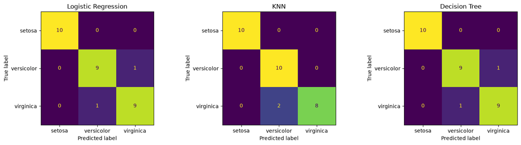

```python
fig, axes = plt.subplots(1, 3, figsize=(15, 4))

for ax, (name, pred) in zip(axes, predictions.items()):
    cm = confusion_matrix(y_test, pred)
    disp = ConfusionMatrixDisplay(
        confusion_matrix=cm,
        display_labels=iris.target_names
    )
    disp.plot(ax=ax, colorbar=False)
    ax.set_title(name)

plt.tight_layout()
plt.show()
```

## Effect of Changing Test Size

The experiment is repeated with `test_size=0.30`. This allocates 70% of the samples for training and 30% for testing.

Changing the test size changes the number of training and testing samples and may affect the measured accuracy.

```python
X_train30, X_test30, y_train30, y_test30 = train_test_split(
    X, y,
    test_size=0.30,
    random_state=42,
    stratify=y
)

model30 = Pipeline([
    ("scaler", StandardScaler()),
    ("classifier", LogisticRegression(max_iter=200))
])

model30.fit(X_train30, y_train30)
pred30 = model30.predict(X_test30)

print("Training set:", X_train30.shape)
print("Testing set:", X_test30.shape)
print("Accuracy with test_size=0.30:",
      accuracy_score(y_test30, pred30))
print("Accuracy with test_size=0.20:",
      accuracy_score(y_test, predictions["Logistic Regression"]))
```

```
Training set: (105, 4)
Testing set: (45, 4)
Accuracy with test_size=0.30: 0.9111111111111111
Accuracy with test_size=0.20: 0.9333333333333333
```

## Effect of StandardScaler

StandardScaler transforms each feature to have approximately zero mean and unit variance based on the training data.

KNN relies on distances between samples, so scaling is particularly important. Logistic Regression may also benefit from scaling. Decision Trees generally do not require feature scaling because their splits depend on feature thresholds.

```python
lr_scaled = Pipeline([
    ("scaler", StandardScaler()),
    ("classifier", LogisticRegression(max_iter=200))
])

lr_unscaled = LogisticRegression(max_iter=200)

lr_scaled.fit(X_train, y_train)
lr_unscaled.fit(X_train, y_train)

pred_scaled = lr_scaled.predict(X_test)
pred_unscaled = lr_unscaled.predict(X_test)

print("Accuracy with scaling:",
      accuracy_score(y_test, pred_scaled))

print("Accuracy without scaling:",
      accuracy_score(y_test, pred_unscaled))
```

```
Accuracy with scaling: 0.9333333333333333
Accuracy without scaling: 0.9666666666666667
```

## Five-Fold Cross-Validation

Cross-validation divides the dataset into five folds. In each iteration, four folds are used for training and one fold is used for validation. Each fold is used once for validation.

The mean accuracy provides a more stable estimate of model performance than a single train-test split.

```python
cv_model = Pipeline([
    ("scaler", StandardScaler()),
    ("classifier", LogisticRegression(max_iter=200))
])

cv_scores = cross_val_score(
    cv_model, X, y,
    cv=5,
    scoring="accuracy"
)

print("Accuracy for each fold:", cv_scores)
print("Mean accuracy:", cv_scores.mean())
print("Standard deviation:", cv_scores.std())
```

```
Accuracy for each fold: [0.96666667 1.         0.93333333 0.9        1.        ]
Mean accuracy: 0.9600000000000002
Standard deviation: 0.038873012632301994
```

```python
pred = predictions["Logistic Regression"]

misclassified = X_test.copy()
misclassified["Actual"] = iris.target_names[y_test.to_numpy()]
misclassified["Predicted"] = iris.target_names[pred]

misclassified = misclassified[
    misclassified["Actual"] != misclassified["Predicted"]
]

print("Misclassified samples:")
print(misclassified)

print("\nNumber of misclassified samples:", len(misclassified))
```

```
Misclassified samples:
     sepal length (cm)  sepal width (cm)  petal length (cm)  petal width (cm)  \
134                6.1               2.6                5.6               1.4
77                 6.7               3.0                5.0               1.7

         Actual   Predicted
134   virginica  versicolor
77   versicolor   virginica

Number of misclassified samples: 2
```

## Model Comparison

The comparison table contains the test accuracy, precision, recall, and F1-score for each classifier.

[output not shown]

The best model is selected based on the observed test results. The best-performing model may vary depending on the split and model settings.

## Result

The Iris flower classification experiment was successfully implemented using Python and Scikit-learn. The dataset was explored and visualized, and Logistic Regression, K-Nearest Neighbours, and Decision Tree classifiers were trained and evaluated.

Accuracy, precision, recall, F1-score, and confusion matrices were used to assess the classification performance. Five-fold cross-validation was also performed to estimate model performance.

## Conclusion

The experiment demonstrates a complete supervised multiclass classification workflow. Petal measurements provide useful information for distinguishing Iris species. Model comparison shows that the choice of classifier, feature scaling, and train-test split can affect the measured performance.